# Analysis of gardasil shots by demographic factors

This program reads data on Gardasil vaccinations in young women. Find more information in the [data dictionary](https://raw.githubusercontent.com/pmean/datasets/master/gardasil.yaml).

The program was written by Steve Simon on 2024-09-07 and is placed in the public domain.

## Load the tidyverse library

For most of your programs, you should load the tidyverse library. The messages and warnings are suppressed.

```r
library(tidyverse)
```

## Read the data and view a brief summary

Use the read_csv function to read the data. The glimpse function will produce a brief summary. Use tolower to convert uppercase to lowercase.

```r
gard <- read_csv(
  file="../data/gardasil.csv",
  col_names=TRUE,
  col_types="nnnnnnnnnn")
names(gard) <- tolower(names(gard))
glimpse(gard)
```

```
Rows: 1,413
Columns: 10
$ age           <dbl> 21, 21, 20, 14, 17, 11, 17, 15, 13, 18, 17, 22, 16, 13, …
$ agegroup      <dbl> 1, 1, 1, 0, 0, 0, 0, 0, 0, 1, 0, 1, 0, 0, 0, 1, 1, 1, 0,…
$ race          <dbl> 0, 0, 0, 0, 3, 1, 0, 3, 3, 0, 1, 0, 3, 1, 1, 0, 1, 1, 0,…
$ shots         <dbl> 3, 3, 1, 3, 2, 1, 1, 3, 3, 3, 2, 2, 1, 2, 1, 1, 1, 3, 3,…
$ completed     <dbl> 1, 1, 0, 1, 0, 0, 0, 1, 1, 1, 0, 0, 0, 0, 0, 0, 0, 1, 1,…
$ insurancetype <dbl> 3, 3, 1, 3, 3, 0, 3, 1, 1, 2, 1, 3, 1, 3, 0, 1, 1, 1, 1,…
$ medassist     <dbl> 0, 0, 0, 0, 0, 1, 0, 0, 0, 0, 0, 0, 0, 0, 1, 0, 0, 0, 0,…
$ location      <dbl> 1, 1, 1, 1, 1, 1, 1, 1, 1, 1, 1, 1, 1, 1, 1, 1, 1, 1, 1,…
$ locationtype  <dbl> 0, 0, 0, 0, 0, 0, 0, 0, 0, 0, 0, 0, 0, 0, 0, 0, 0, 0, 0,…
$ practicetype  <dbl> 1, 1, 1, 0, 1, 0, 1, 0, 0, 1, 0, 1, 0, 0, 0, 1, 1, 1, 1,…
```

## Question 7: First create factors for medassist

The factor function identifies a variable as categorical and assigns labels to number codes. You don’t necessarily need to use factor if the data you read in is character strings, as R automatically treats those variable as categorical.

```r
gard$medassist <- factor(
  gard$medassist,
  levels=0:1,
  labels=c(
    "No medical assistance",
    "Received medical assistance"))
```

## Question 7: Summarize and interpret the percentage of patients receiving medical assistance. Be sure to convert the number codes for this variable into labels using the factor function

```r
gard |>
  count(medassist) |>
  mutate(total=sum(n)) |>
  mutate(pct=round(100*n/total))
```

```
# A tibble: 2 × 4
  medassist                       n total   pct
  <fct>                       <int> <int> <dbl>
1 No medical assistance        1138  1413    81
2 Received medical assistance   275  1413    19
```

## Create factors for shots

It is a bit silly to replace 1, 2, 3 with One, Two, Three. The main reason is to clearly identify shots as categorical rather than continuous.

```r
gard$shots <- factor(
  gard$shots,
  levels=1:3,
  labels=c(
    "One",
    "Two",
    "Three"))
```

## Counts and percentages for shots

```r
gard |>
  count(shots) |>
  mutate(total=sum(n)) |>
  mutate(pct=round(100*n/total))
```

```
# A tibble: 3 × 4
  shots     n total   pct
  <fct> <int> <int> <dbl>
1 One     440  1413    31
2 Two     436  1413    31
3 Three   537  1413    38
```

Slightly more patients got three shots than one or two shots, but this is still less than half of the patients overall.

## Question 8: First calculate the percentages for number of shots received by whether the patient received medical assistance. Interpret this chart.

```r
gard |>
  count(medassist, shots) |>
  group_by(medassist) |>
  mutate(row_total=sum(n)) |>
  mutate(pct=round(100*n/row_total))
```

```
# A tibble: 6 × 5
# Groups:   medassist [2]
  medassist                   shots     n row_total   pct
  <fct>                       <fct> <int>     <int> <dbl>
1 No medical assistance       One     329      1138    29
2 No medical assistance       Two     342      1138    30
3 No medical assistance       Three   467      1138    41
4 Received medical assistance One     111       275    40
5 Received medical assistance Two      94       275    34
6 Received medical assistance Three    70       275    25
```

Surprisingly 41% of patients who did not receive medical assistance received all three shots when compared to the 25% of patients who received medical assistance.

## ## Question 8: Draw a bar chart showing the percentages for number of shots received by whether the patient received medical assistance. Interpret this chart.

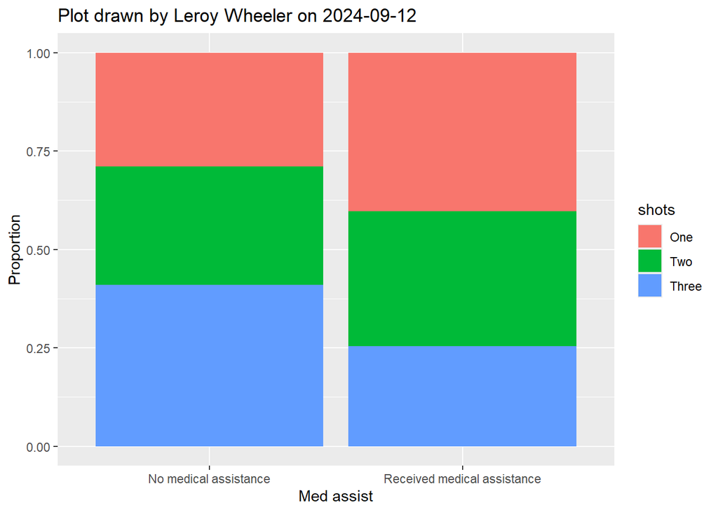

```r
gard |>
  ggplot(aes(x=medassist, fill=shots)) +
    geom_bar(position="fill") +
    xlab("Med assist") +
    ylab("Proportion") +
    ggtitle("Plot drawn by Leroy Wheeler on 2024-09-12")
```

Patients who did not receive medical assistance were more likely to complete the full round of three Gardisil shots compared to patients who received some medical assistance.